# Assignment 10

Samira Zarandioon

April 1, 2017

1. Fist we download the data:

   ```r
   library(downloader)
   download("http://stat.columbia.edu/~rachel/datasets/nyt1.csv", destfile="nyt1.csv")
   ```

2. Add new variable ageGroup for the following groups: < 18, 18–24, 25–34, 35–44, 45–54, 55–64 and 65+

   ```r
   nyt_dataframe <- read.csv("nyt1.csv", stringsAsFactors=FALSE, header=TRUE)
   nyt_dataframe$ageGroup[nyt_dataframe$Age<18] <- "<18"
   nyt_dataframe$ageGroup[nyt_dataframe$Age>=18 & nyt_dataframe$Age<=24 ] <- "18–24"
   nyt_dataframe$ageGroup[nyt_dataframe$Age>=25 & nyt_dataframe$Age<=34 ] <- "25-34"
   nyt_dataframe$ageGroup[nyt_dataframe$Age>=35 & nyt_dataframe$Age<=44 ] <- "35–44"
   nyt_dataframe$ageGroup[nyt_dataframe$Age>=45 & nyt_dataframe$Age<=54 ] <- "45–54"
   nyt_dataframe$ageGroup[nyt_dataframe$Age>=55 & nyt_dataframe$Age<=64 ] <- "55–64"
   nyt_dataframe$ageGroup[nyt_dataframe$Age>=65] <- "65+"
   ```

3. Create a sub data set called ImpSub that contains rows with Impressions>0:

   ```r
   ImpSub<-nyt_dataframe[nyt_dataframe$Impressions>0,]
   ```

4. Create a new variable called click-through-rate (CTR = click/impression)

   ```r
   ImpSub$CTR = ImpSub$Clicks / ImpSub$Impressions
   ```

5. Use this ImpSub data set to do further analysis.
6. Plot distributions of number impressions and click-through-rate (CTR = click/impression) for the age groups.

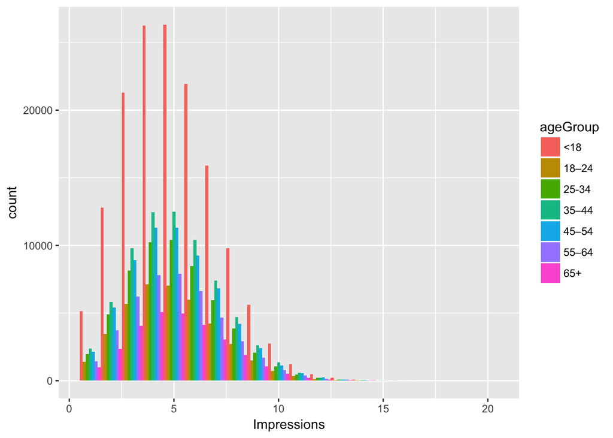

   ```r
   #install.packages("ggplot2")
   library(ggplot2)
   ggplot(ImpSub, aes(x=Impressions, fill=ageGroup)) +
       geom_histogram(binwidth=1, position="dodge")
   ```

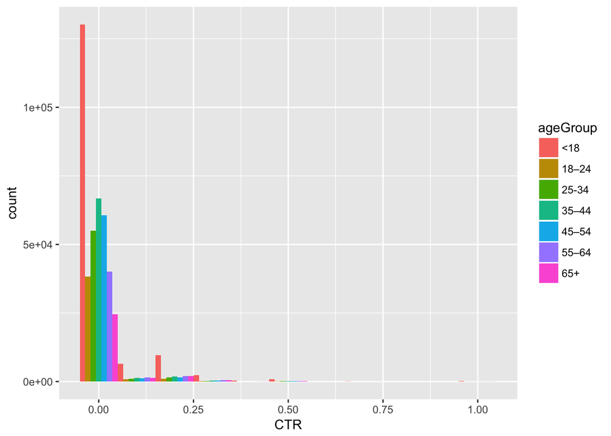

   ```r
   #install.packages("ggplot2")
   library(ggplot2)
   ggplot(ImpSub, aes(x=CTR, fill=ageGroup)) +
       geom_histogram(binwidth=.1, position="dodge")
   ```

7. Define a new variable to segment users based on click -through-rate (CTR) behavior CTR< 0.2, 0.2<=CTR <0.4, 0.4<= CTR<0.6, 0.6<=CTR<0.8, CTR>0.8.

   ```r
   ImpSub$CTRGroup[ImpSub$CTR<.2] <- "CTR<0.2"
   ImpSub$CTRGroup[ImpSub$CTR>=.2 & ImpSub$CTR<.4] <- ".2<=CTR<0.4"
   ImpSub$CTRGroup[ImpSub$CTR>=.4 & ImpSub$CTR<.6] <- ".4<=CTR<0.6"
   ImpSub$CTRGroup[ImpSub$CTR>=.6 & ImpSub$CTR<.8] <- ".6<=CTR<0.8"
   ImpSub$CTRGroup[ImpSub$CTR>=.8] <- "CTR>=0.8"
   ```

8. Get the total number of Male, Impressions, Clicks and Signed_In (0=Female, 1=Male)

   ```r
   cat("Number of Male: ",sum(ImpSub$Gender),"\n")
   ```

   ```
   ## Number of Male:  167146
   ```

   ```r
   cat("Number of Impressions: ",sum(ImpSub$Impressions),"\n")
   ```

   ```
   ## Number of Impressions:  2295559
   ```

   ```r
   cat("Number of Clicks: ",sum(ImpSub$Clicks),"\n")
   ```

   ```
   ## Number of Clicks:  42449
   ```

   ```r
   cat("Number of Signed In: ",sum(ImpSub$Signed_In))
   ```

   ```
   ## Number of Signed In:  319198
   ```

9. Get the mean of Age, Impressions, Clicks, CTR and percentage of males and signed_In

   ```r
   cat("Average of Age: ",mean(ImpSub$Age),"\n")
   ```

   ```
   ## Average of Age:  29.48401
   ```

   ```r
   cat("Average of Impressions: ",mean(ImpSub$Impressions),"\n")
   ```

   ```
   ## Average of Impressions:  5.04103
   ```

   ```r
   cat("Average of Clicks: ",mean(ImpSub$Clicks),"\n")
   ```

   ```
   ## Average of Clicks:  0.09321768
   ```

   ```r
   cat("Average of CTR: ",mean(ImpSub$CTR),"\n")
   ```

   ```
   ## Average of CTR:  0.01847053
   ```

   ```r
   cat("Percentage of Males: ", 100 * sum(ImpSub$Gender)/nrow(ImpSub),"\n")
   ```

   ```
   ## Percentage of Males:  36.70513
   ```

   ```r
   cat("Percentage of Signed In: ", 100 * sum(ImpSub$Signed_In)/nrow(ImpSub),"\n")
   ```

   ```
   ## Percentage of Signed In:  70.09564
   ```

10. Get the means of Impressions, Clicks, CTR and percentage of males and signed_In by AgeGroup.

    ```r
    aggregate(ImpSub[,c("Age","Impressions","Clicks","CTR")],list(ImpSub$ageGroup),mean)
    ```

    ```
    ##   Group.1       Age Impressions     Clicks         CTR
    ## 1     <18  1.397948    5.034534 0.14372052 0.028530995
    ## 2   18–24 20.832187    5.038235 0.05362799 0.010733764
    ## 3   25-34 29.503573    5.026055 0.05081227 0.010146329
    ## 4   35–44 39.493195    5.054749 0.05202148 0.010286330
    ## 5   45–54 49.492928    5.045172 0.05062260 0.009957612
    ## 6   55–64 59.497459    5.053484 0.10246952 0.020306816
    ## 7     65+ 72.988409    5.046925 0.15233226 0.029802702
    ```

    ```r
    aggregate(list(male_perc=ImpSub$Gender,signed_in_perc=ImpSub$Signed_In), by=list(age_group=ImpSub$ageGroup), FUN = function(x) 100*sum(x)/length(x) )
    ```

    ```
    ##   age_group male_perc signed_in_perc
    ## 1       <18  6.270471       9.160224
    ## 2     18–24 53.395367     100.000000
    ## 3     25-34 53.199772     100.000000
    ## 4     35–44 53.170725     100.000000
    ## 5     45–54 52.921920     100.000000
    ## 6     55–64 53.596329     100.000000
    ## 7       65+ 36.325116     100.000000
    ```

11. Create a table of CTRGroup vs AgeGroup counts.

    ```r
    aggregate(list(count=ImpSub$ageGroup), by=list(age_group=ImpSub$ageGroup, ctr_group=ImpSub$CTRGroup), FUN = length )
    ```

    ```
    ##    age_group   ctr_group  count
    ## 1        <18 .2<=CTR<0.4   8724
    ## 2      18–24 .2<=CTR<0.4    858
    ## 3      25-34 .2<=CTR<0.4   1203
    ## 4      35–44 .2<=CTR<0.4   1489
    ## 5      45–54 .2<=CTR<0.4   1331
    ## 6      55–64 .2<=CTR<0.4   1793
    ## 7        65+ .2<=CTR<0.4   1742
    ## 8        <18 .4<=CTR<0.6   1143
    ## 9      18–24 .4<=CTR<0.6     99
    ## 10     25-34 .4<=CTR<0.6    110
    ## 11     35–44 .4<=CTR<0.6    124
    ## 12     45–54 .4<=CTR<0.6    125
    ## 13     55–64 .4<=CTR<0.6    201
    ## 14       65+ .4<=CTR<0.6    195
    ```

    [output cut: 20 more lines]

12. Plot distributions of number impressions and click-through-rate (CTR = click/impression) for the age groups This is a duplicate question. Please see the question number 6 for the answer.
13. One more plot you think which is important to look at. The following graphs show the distribution of impressions based on CTRGroups:

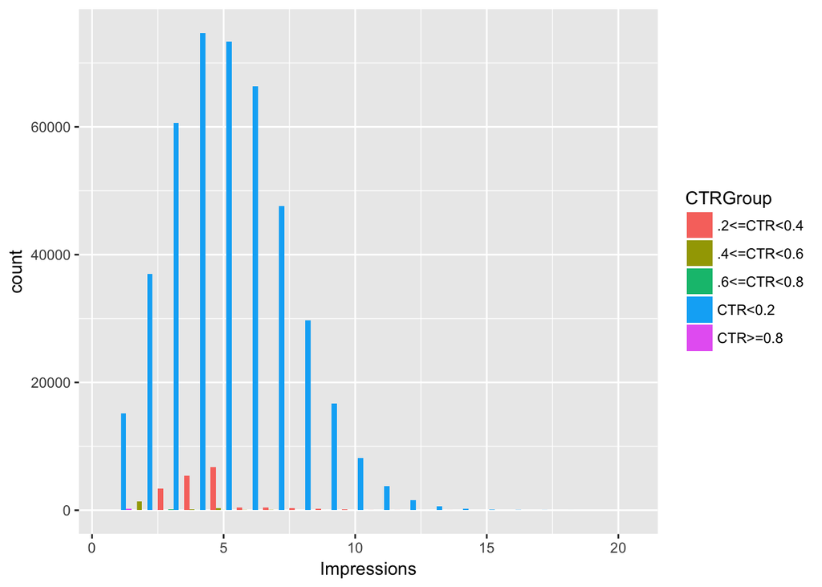

    ```r
    #install.packages("ggplot2")
    library(ggplot2)
    ggplot(ImpSub, aes(x=Impressions, fill=CTRGroup)) +
        geom_histogram(binwidth=1, position="dodge")
    ```

14. Submit your file (any format) in to Live session Unit 10 Assignment